# Hands-on Practical: Generalised Additive Models (GAMs) with Bioluminescence

## Part C – Mixed Effects Models: The Right Way (25 minutes)

### Task C1: Random Intercept Model

**What you’ll do**: Fit a mixed model that allows each nest to have its own baseline level.

```r
# Fit mixed model with random intercepts for each nest
# (1 | Nest) means "let each nest have its own intercept"
model_ri <- lmer(logNeg ~ FoodTreatment + SexParent + ArrivalTime  + BroodSize +
                   (1 | Nest),
                 data = owls,
                 REML = TRUE)

summary(model_ri)
```

```
## Linear mixed model fit by REML. t-tests use Satterthwaite's method [
## lmerModLmerTest]
## Formula: logNeg ~ FoodTreatment + SexParent + ArrivalTime + BroodSize +
##     (1 | Nest)
##    Data: owls
##
## REML criterion at convergence: 1370
##
## Scaled residuals:
##      Min       1Q   Median       3Q      Max
## -2.33482 -0.79530 -0.01034  0.71359  3.06137
##
## Random effects:
##  Groups   Name        Variance Std.Dev.
##  Nest     (Intercept) 0.09655  0.3107
##  Residual             0.52336  0.7234
## Number of obs: 599, groups:  Nest, 27
##
## Fixed effects:
##                        Estimate Std. Error        df t value Pr(>|t|)
## (Intercept)             3.03155    0.46923 237.48573   6.461 5.85e-10 ***
## FoodTreatmentSatiated  -0.56919    0.06258 591.54224  -9.095  < 2e-16 ***
## SexParentMale           0.07067    0.06674 589.02871   1.059    0.290
## ArrivalTime            -0.09585    0.01600 584.69756  -5.989 3.70e-09 ***
## BroodSize              -0.00545    0.05531  21.12728  -0.099    0.922
## ---
## Signif. codes:  0 '***' 0.001 '**' 0.01 '*' 0.05 '.' 0.1 ' ' 1
##
## Correlation of Fixed Effects:
##             (Intr) FdTrtS SxPrnM ArrvlT
## FdTrtmntStt -0.093
## SexParentMl -0.031  0.069
## ArrivalTime -0.855  0.035 -0.052
## BroodSize   -0.508 -0.012 -0.031  0.027
```

**Questions to answer**:

### Task C2: Random Intercept + Slope Model

**What you’ll do**: Allow each nest to have both its own baseline AND its own response to arrival time.

```r
# Fit mixed model with random intercepts AND slopes
# (1 + ArrivalTime | Nest) means "let each nest have its own intercept AND slope for ArrivalTime"
model_ris <- lmer(logNeg ~ FoodTreatment + SexParent  + BroodSize +
                    (1 + ArrivalTime | Nest), # if I do it the other way around, it tries to fit a separate random intercept and slope for every unique value of ArrivalTime, which doesn't make sense and is also far too many parameters
                  data = owls,
                  REML = TRUE)
summary(model_ris)
```

```
## Linear mixed model fit by REML. t-tests use Satterthwaite's method [
## lmerModLmerTest]
## Formula: logNeg ~ FoodTreatment + SexParent + BroodSize + (1 + ArrivalTime |
##     Nest)
##    Data: owls
##
## REML criterion at convergence: 1368.4
##
## Scaled residuals:
##      Min       1Q   Median       3Q      Max
## -2.37044 -0.75256  0.03635  0.69371  2.98071
##
## Random effects:
##  Groups   Name        Variance Std.Dev. Corr
##  Nest     (Intercept) 5.114419 2.2615
##           ArrivalTime 0.008064 0.0898   -0.99
##  Residual             0.513033 0.7163
## Number of obs: 599, groups:  Nest, 27
##
## Fixed effects:
##                        Estimate Std. Error        df t value Pr(>|t|)
## (Intercept)             0.55582    0.22371  23.29472   2.485   0.0206 *
## FoodTreatmentSatiated  -0.54843    0.06271 574.21573  -8.745   <2e-16 ***
## SexParentMale           0.07964    0.06635 555.00146   1.200   0.2305
## BroodSize               0.01004    0.05057  20.35446   0.198   0.8447
## ---
## Signif. codes:  0 '***' 0.001 '**' 0.01 '*' 0.05 '.' 0.1 ' ' 1
##
## Correlation of Fixed Effects:
##             (Intr) FdTrtS SxPrnM
## FdTrtmntStt -0.130
## SexParentMl -0.154  0.072
## BroodSize   -0.932 -0.017 -0.037
## optimizer (nloptwrap) convergence code: 0 (OK)
## Model failed to converge with max|grad| = 0.937769 (tol = 0.002, component 1)
```

**Questions to answer**:

1. What is the correlation between random intercepts and slopes? -0.99
2. Is this correlation positive or negative? negative
3. What does this correlation mean biologically? Negative correlation between random intercepts and slopes means that nests with higher levels of negotiation calls (higher intercepts) tend to have lower slopes (arrival time) => negotiation call rate changes less (or even decreases) with arrival time. On the other side, nests with lower negotiation calls tend to increase negotiation calls more strongly as arrival time changes. This suggests a trade-off: nests that start with high negotiation activity are less responsive to arrival time changes, while nests with lower negotiation activity in the beginning are more responsive.

### Task C3: Compare the Two Models

**What you’ll do**: Statistically test which model fits better.

```r
# Compare the two models
anova(model_ri, model_ris)
```

```
## Data: owls
## Models:
## model_ri: logNeg ~ FoodTreatment + SexParent + ArrivalTime + BroodSize + (1 | Nest)
## model_ris: logNeg ~ FoodTreatment + SexParent + BroodSize + (1 + ArrivalTime | Nest)
##           npar    AIC    BIC  logLik -2*log(L) Chisq Df Pr(>Chisq)
## model_ri     7 1362.7 1393.5 -674.36    1348.7
## model_ris    8 1363.2 1398.3 -673.57    1347.2 1.564  1     0.2111
```

**Questions to answer**:

## Part D – Understanding What Mixed Models Do (15 minutes)

### Task D1: Calculate Intraclass Correlation (ICC)

**What you’ll do**: Find out how much observations within the same nest resemble each other.

```r
# Extract variance components of the mixed model model
variance_components <- as.data.frame(VarCorr(model_ris))

# Get between-NEST variance
between_nest_var <- variance_components$vcov[variance_components$grp == "Nest"]

# Get within-nest variance  of the mixed model mode
within_nest_var <- sigma(model_ris)^2

# Calculate ICC (Intraclass Correlation Coefficient)
icc <- between_nest_var / (between_nest_var + within_nest_var)

cat("ICC =", round(icc, 3),
"\nThis means", round(icc * 100, 1), "% of variation is between nests")
```

```
## ICC = 0.909 0.015 -0.647
## This means 90.9 1.5 -64.7 % of variation is between nests
```

**Questions to answer**:

1. What is the ICC value? ICC = 0.909 0.015 -0.647
2. What percentage of variation is between nests? This means 90.9% of variation is between nests
3. Is this a high or low level of clustering? high - most of the variation in log-transformed negotiation calls ( which is the outcome variable) comes from differences between nests, not within nests

### Task D2: Visualize Model Predictions

**What you’ll do**: See how the model makes predictions for population vs individual nests.

```r
# Create data for predictions
pred_data <- tibble(
  ArrivalTime = seq(min(owls$ArrivalTime), max(owls$ArrivalTime), length.out = 100),
  FoodTreatment = factor("Deprived", levels = levels(owls$FoodTreatment)),
  SexParent = factor("Male", levels = levels(owls$SexParent)),
  BroodSize = median(owls$BroodSize)
)

str(pred_data)
```

```
## tibble [100 × 4] (S3: tbl_df/tbl/data.frame)
##  $ ArrivalTime  : num [1:100] 21.7 21.8 21.9 21.9 22 ...
##  $ FoodTreatment: Factor w/ 2 levels "Deprived","Satiated": 1 1 1 1 1 1 1 1 1 1 ...
##  $ SexParent    : Factor w/ 2 levels "Female","Male": 2 2 2 2 2 2 2 2 2 2 ...
##  $ BroodSize    : num [1:100] 4 4 4 4 4 4 4 4 4 4 ...
```

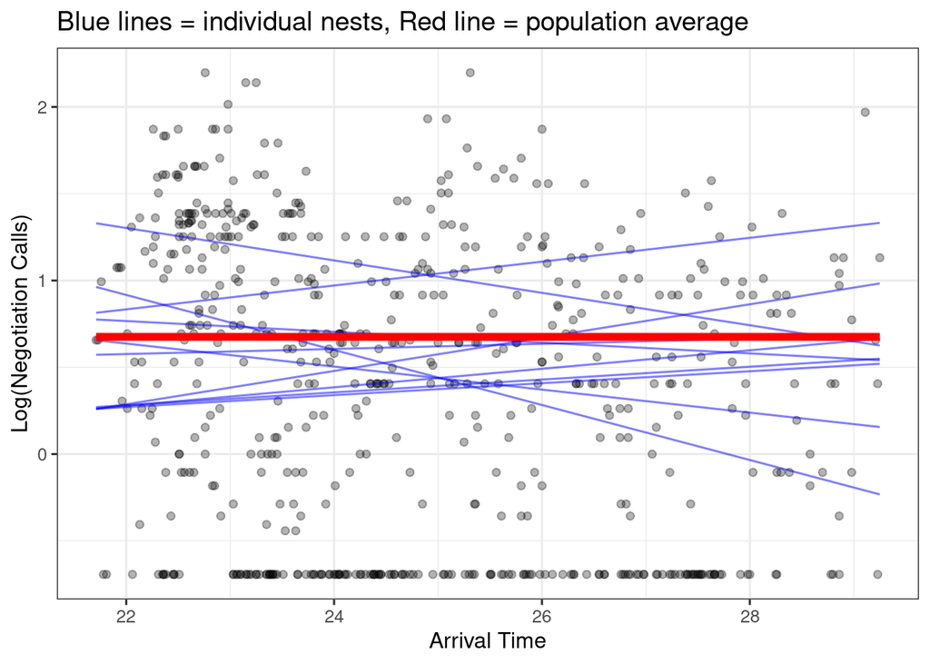

```r
# Population-level prediction (ignoring random effects)
pred_data$population_fit <- predict(model_ris, newdata = pred_data, re.form = NA)

# Create nest-specific predictions
# Create the data frame first
nest_data <- owls |>
  distinct(Nest) |>
  slice_head(n = 10) |>
  crossing(pred_data)

# Then add predictions
nest_predictions <- nest_data |>
  mutate(nest_fit = predict(model_ris, newdata = nest_data, re.form = ~ (1 + ArrivalTime | Nest)))

# Plot
ggplot() +
  geom_point(data = owls, aes(x = ArrivalTime, y = logNeg), alpha = 0.3) +
  geom_line(data = nest_predictions,
            aes(x = ArrivalTime, y = nest_fit, group = Nest),
            alpha = 0.5, color = "blue") +
  geom_line(data = pred_data,
            aes(x = ArrivalTime, y = population_fit),
            size = 2, color = "red") +
  labs(
    title = "Blue lines = individual nests, Red line = population average",
    x = "Arrival Time",
    y = "Log(Negotiation Calls)"
  )
```

**Questions to answer**:

1. Do the blue lines (individual nests) vary around the red line (population average)? yes
2. Where is the variation between nests greatest - at early or late arrival times? arival time

## Part E – Model Checking (15 minutes)

### Task E1: Check Model Assumptions

**What you’ll do**: Make sure our model is reasonable by checking the residuals.

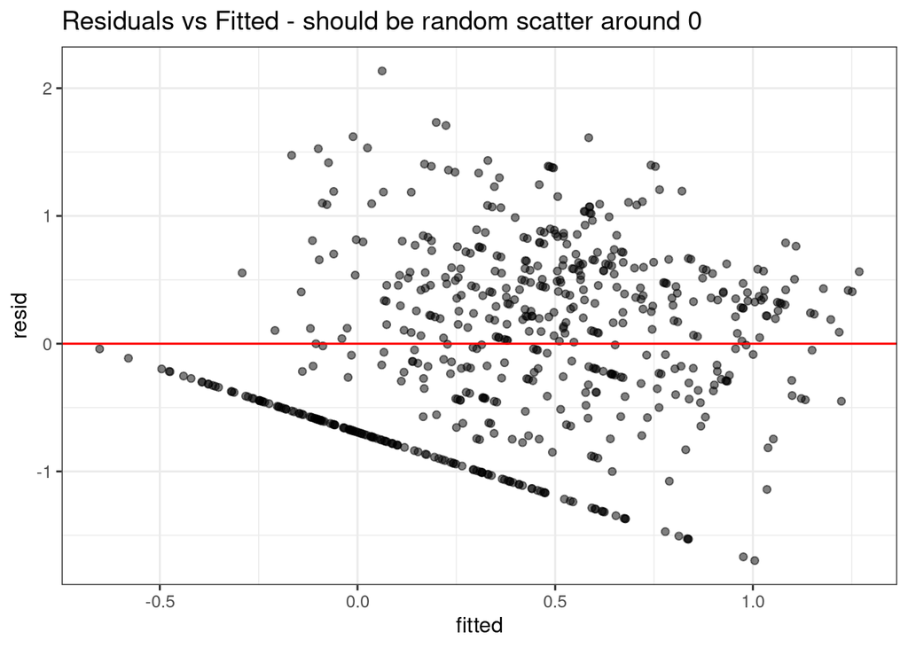

```r
# Choose our final model (let's assume random slopes was better)
final_model <- model_ris

# Get standardized residuals
residuals <- resid(final_model, type = "pearson")

# 1. Residuals vs fitted values
fitted_values <- fitted(final_model)
ggplot(data.frame(fitted = fitted_values, resid = residuals),
       aes(fitted, resid)) +
  geom_point(alpha = 0.5) +
  geom_hline(yintercept = 0, color = "red") +
  labs(title = "Residuals vs Fitted - should be random scatter around 0")
```

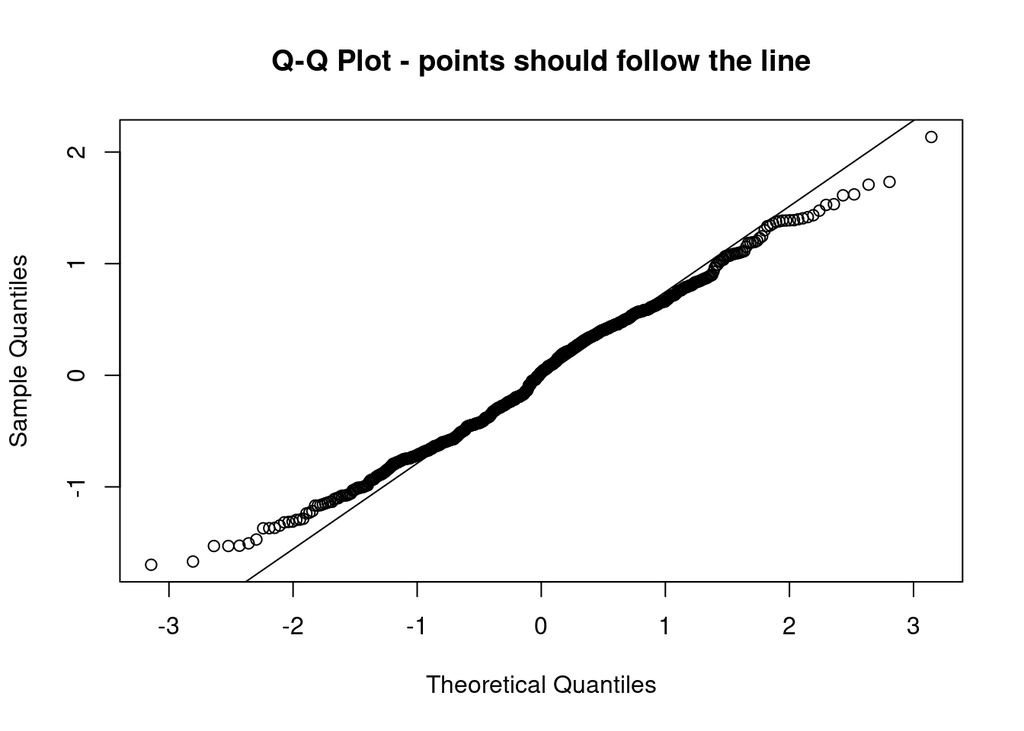

```r
# 2. Check normality of residuals
qqnorm(residuals, main = "Q-Q Plot - points should follow the line")
qqline(residuals)
```

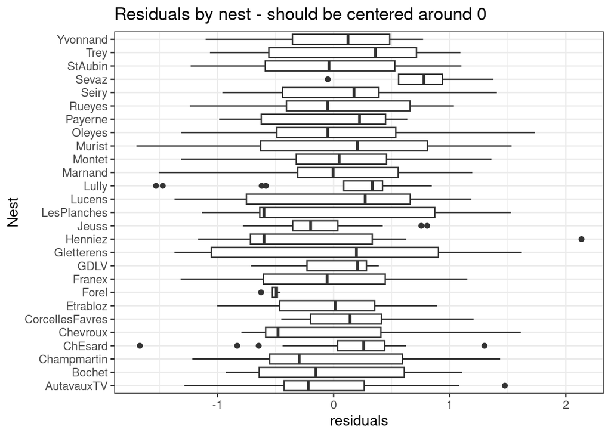

```r
# 3. Check residuals by nest
data.frame(Nest = owls$Nest, residuals = residuals) %>%
  ggplot(aes(Nest, residuals)) +
  geom_boxplot() +
  coord_flip() +
  labs(title = "Residuals by nest - should be centered around 0")
```

**Questions to answer**:

1. In the residuals vs fitted plot, do you see any clear patterns? yes, a linear negative pattern
2. In the QQ plot, do the residuals appear normally distributed? yes
3. Are there any nests with unusual residual patterns? some of them have outliers and a few are not centered around 0

### Task E2: Look at Random Effects

**What you’ll do**: See which nests are unusual.

```r
# Extract random effects (how each nest differs from average)
random_effects <- ranef(final_model)

# Look at first few
head(random_effects$Nest)
```

```
##                 (Intercept) ArrivalTime
## AutavauxTV        -1.570008  0.05330527
## Bochet             3.728299 -0.15850055
## Champmartin        1.420495 -0.06632691
## ChEsard            2.681446 -0.09338252
## Chevroux          -2.501273  0.09603170
## CorcellesFavres   -1.352890  0.06869393
```

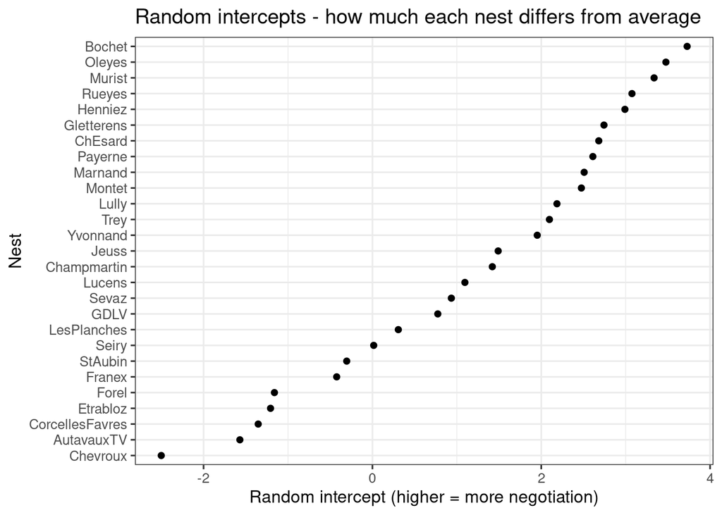

```r
# Make a caterpillar plot of random intercepts
re_data <- as.data.frame(random_effects$Nest) %>%
  rownames_to_column("Nest") %>%
  rename(random_intercept = `(Intercept)`)

ggplot(re_data, aes(x = reorder(Nest, random_intercept), y = random_intercept)) +
  geom_point() +
  coord_flip() +
  labs(
    title = "Random intercepts - how much each nest differs from average",
    x = "Nest",
    y = "Random intercept (higher = more negotiation)"
  )
```

**Questions to answer**:

1. Which nest has the highest random intercept? Bochet
2. Which nest has the lowest random intercept? Chevroux
3. What does a positive random intercept mean? for a specific nest, the predicted baseline value of the outcome variable is higher than the overall average baseline

## Summary Questions

**Answer these questions based on your analysis**:

1. Why can’t we treat all observations as independent in this dataset?  
   Because observations come from chicks within the same nest. This means that there is not independence
2. What’s the main advantage of mixed models over separate analyses for each nest?  
   Mixed models allow us to use all data at once while accounting for nest-level variation through random effects
3. What does the random intercept capture in our model?  
   baseline differences in negotiation calls between nests
4. What does the random slope capture in our model?  
   how the effect of ArrivalTime on negotiation calls differs across nests
5. Based on your model, does arrival time significantly affect sibling negotiation?  
   yes
6. Do you think the mixed model approach was necessary for this dataset? Why?  
   yes, because of the non-independence in our data (nests)